# Weekly Update for April 9

## Show and Tell April 9

## Sample User

## Sample Slide

A sample list:

1. O-Ren Ishii
2. Vernita Green
3. Budd
4. Elle Driver
5. Bill

## Ganesh

## Nist Scans: Type II Error rate and Failed Tests

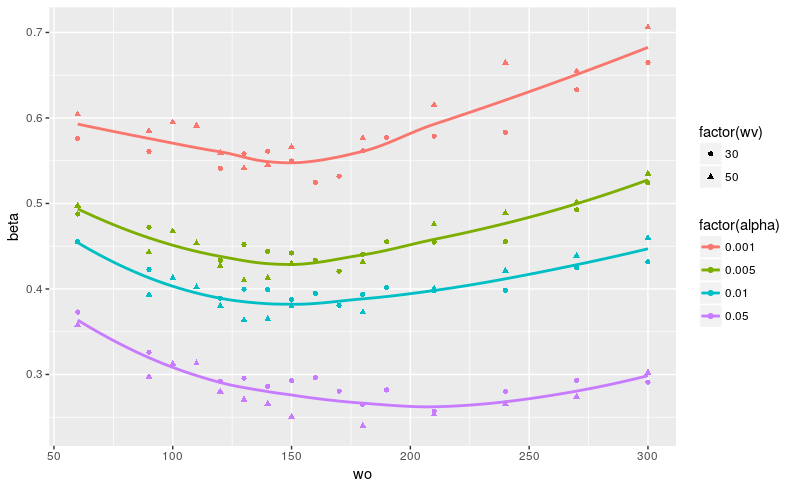

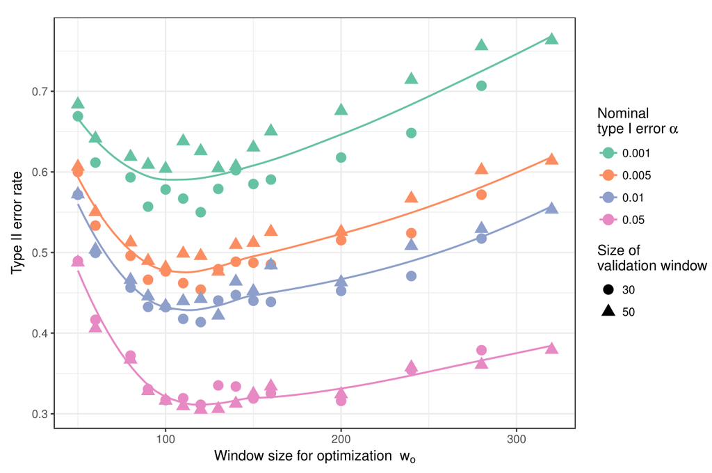

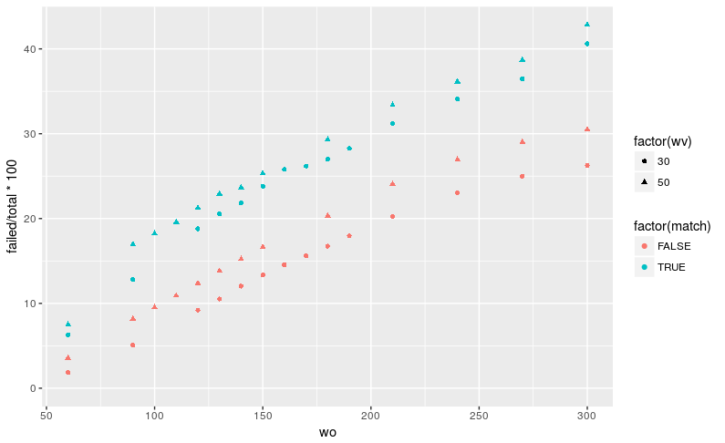

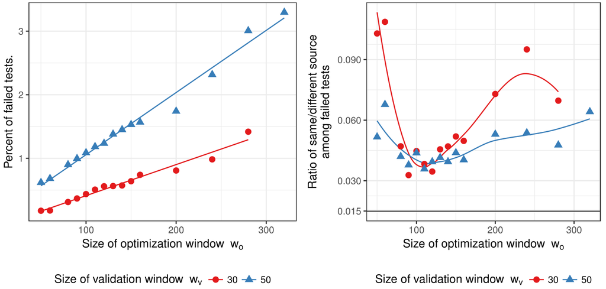

## Kiegan

## Book Progress & Modeling & Writeups, Oh My!

1. **Chapman and Hall book**: Progress! Did a lot of research and some writing. Rounding out the chapter this week.
2. **Grooves Writeup**: Started a write-up of methods we are trying for groove identification
3. **Modeling**: Trying out a new method. First predicting whether a groove is there or not!
4. **Hands-On Stuff**: Going through and identifying where there are grooves/where there are not for test set.
5. **Reading Group Talk!**: On NIJ Fellowships. Get excited!
6. Plots coming next week… :)

## Nate

## Bivariate SLR Weirdness

- score(x,y) = (|x - y|, |y|)
- x is the known source measurement
- y is the unknown trace measurement

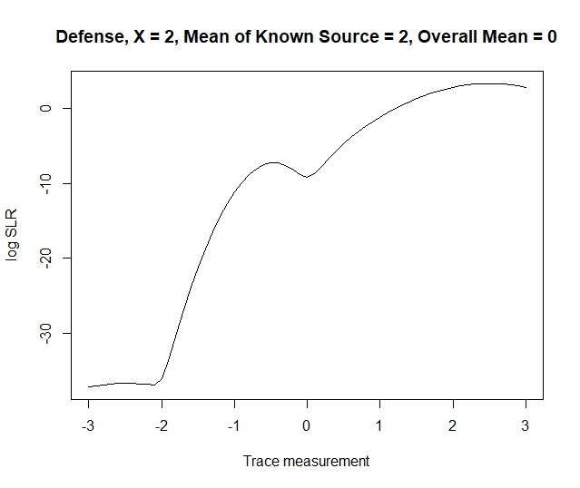

## Bivariate SLR Weirdness cont.

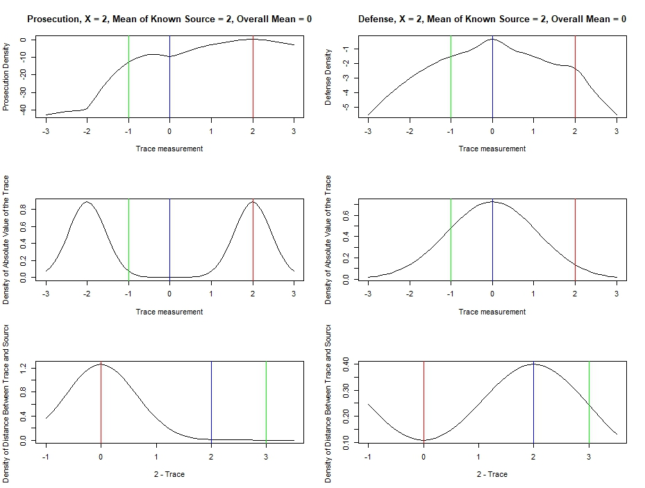

## Sam

## Writing away

- Glass chapter
- Thompson redo
- Judge training
- REU plans, lectures, assignments, etc.

## Martin

## Shoeprint registration in MATLAB

- Made it work after changing affine transformation to rigid transformation (translation and rotation only)
- The alignment is good enough to make comparisons. Not perfect just due to differences in the images
- Working right now on writing a script to align all images to date images per size and model

## Example

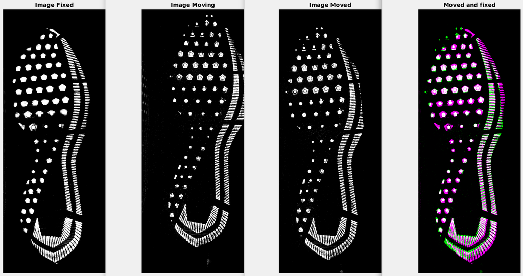

## Nick

## Cleaning

Stentiford, Fred and R. G. Mortimer. “Some new heuristics for thinning binary handprinted characters for OCR” IEEE Transactions on Systems, Man, and Cybernetics SMC-13 (1983): 81-84.

- Implement pre-processing from the paper above.
- 13 steps based on masks
- Goals: Remove “spurrious projections”, fill “noise holes”, limit “necking effect”, eliminate “acute angle tails”
  - Current processing fills “noise holes” only
- All of this is done with the goal of making processing more robust so differences in thinned writing come from writing, not processing.

## Amy

## Handwriting

- Latent Dirichlet Allocation (LDA) - Thanks Danica! :)
- Results from modeling next week!

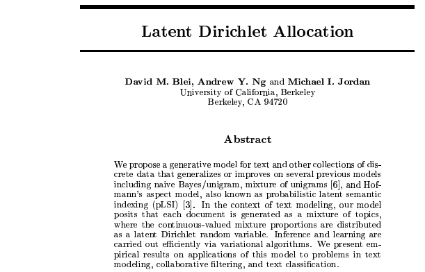

- **Next:** Nick’s graph counts & next level data!